# Forbes List Analysis

Josia Schramm, Bernhard Eymann, Nico Joller

2024-03-29

## Research Question

We want to explore and analyze the Forbes List of the richest people in the world. We want to find out if the distribution of wealth is equal among the continents and the industries and if there is a correlation between age and net worth. Our hypotheses are 1: The distribution of wealth is not equal among the continents. 2: The distribution of wealth is not equal among the industries. 3: There is a correlation between age and net worth.

## Load Data, libraries

We load the tidyverse library and the data from the data_orig folder.

```r
library(tidyverse)
data_orig <- read.csv(here::here("data_orig", "forbes_richman.csv"))
```

## Data cleaning, transformation and summary

We clean the data by removing any non-numeric and period chars from the Net.Worth column and by transforming the Age column into a numeric column. We also sort the countries into continents and the industries into fewer categories. We drop missing values and transform the character columns into factors. And print a summary of the interesting columns.

```r
# Check class of cols and output tables of cols to see whats in it
# sapply(data_orig, class)
# sapply(data_orig, table)

# summary(data_orig)


# remove non integer and non "." in Net.Worth
remove_non_integer <- function(vector) {
  vector <- str_replace_all(vector, "[^0-9.]", "")
  vector <- as.numeric(vector)
  return(vector)
}

# assign original data to working df
df <- data_orig

# apply function to clean net worth
df$Net.Worth <- remove_non_integer(data_orig$Net.Worth)

# Set missing values in Age to NA
# reassign countries to continents
# reassign industry to fewer categories
# mutate chars into factors, mutate age into numeric
# drop missing values
df <- df %>%
  mutate(Age = ifelse(Age == "N/A", NA, Age)) %>%
  mutate(Age = as.numeric(Age)) %>%
  mutate(Country = ifelse(Country %in% c("Canada", "United States"), "North America", Country)) %>%
  mutate(Country = ifelse(Country %in% c("Argentina", "Barbados", "Belize", "Brazil", "Chile", "Colombia","Macau", "Guernsey", "Mexico", "Peru", "St. Kitts and Nevis", "Uruguay", "Venezuela"), "South America", Country)) %>%
  mutate(Country = ifelse(Country %in% c("Austria","Belgium", "Bulgaria", "Cyprus", "Czechia", "Denmark", "Estonia", "Finland", "France", "Georgia", "Germany", "Greece", "Hungary", "Iceland", "Ireland", "Israel", "Italy", "Liechtenstein", "Monaco", "Netherlands", "Norway", "Poland", "Portugal", "Romania", "Russia", "Slovakia", "Spain", "Sweden", "Switzerland", "Ukraine", "United Kingdom"),"Europe", Country)) %>%
  mutate(Country = ifelse(Country %in% c("China", "Hong Kong", "India", "Indonesia", "Japan", "Kazakhstan", "Lebanon", "Malaysia", "Nepal", "Oman", "Philippines", "Qatar", "Singapore", "South Korea", "Taiwan", "Thailand", "Turkey", "United Arab Emirates", "Vietnam"),"Asia", Country)) %>%
  mutate(Country = ifelse(Country %in% c("Algeria", "Egypt", "Eswatini (Swaziland)", "Morocco", "Nigeria", "South Africa", "Tanzania" ),"Africa", Country)) %>%
  mutate(Country = ifelse(Country %in% c("Australia", "New Zealand"),"Asia", Country)) %>%
  mutate(Industry = ifelse(Industry %in% c("Energy", "Technology", "Telecom", "Construction & Engineering"), "Energy & Technology", Industry)) %>%
  mutate(Industry = ifelse(Industry %in% c("Fashion & Retail", "Food & Beverage", "Gambling & Casinos", "Media & Entertainment", "Service", "Sports"),"Entertainment & Consumption", Industry)) %>%
  mutate(Industry = ifelse(Industry %in% c("Automotive Construction & Engineering ", "Manufacturing", "Logistics", "Metals & Mining", "Automotive"),"Industrial & Manufacturing", Industry)) %>%
  mutate(Industry = ifelse(Industry %in% c("Real Estate", "Finance & Investments"),"Real Estate & Finance", Industry)) %>%
  mutate(across(c(Name, Country, Source, Industry),as.factor)) %>%
  drop_na()


# print summary of interesting cols
summary(df[,c("Age", "Net.Worth", "Industry", "Country")])
```

```
##       Age          Net.Worth                              Industry
##  Min.   : 19.0   Min.   :  1.000                              :  0
##  1st Qu.: 55.0   1st Qu.:  1.500   Diversified                :166
##  Median : 64.0   Median :  2.400   Energy & Technology        :473
##  Mean   : 64.3   Mean   :  4.803   Entertainment & Consumption:601
##  3rd Qu.: 74.0   3rd Qu.:  4.300   Healthcare                 :196
##  Max.   :100.0   Max.   :219.000   Industrial & Manufacturing :462
##                                    Real Estate & Finance      :532
##           Country
##               :   0
##  Africa       :  19
##  Asia         :1018
##  Europe       : 559
##  North America: 737
##  South America:  97
##
```

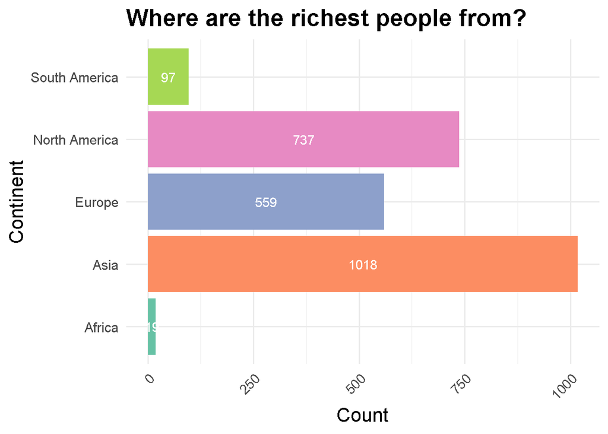

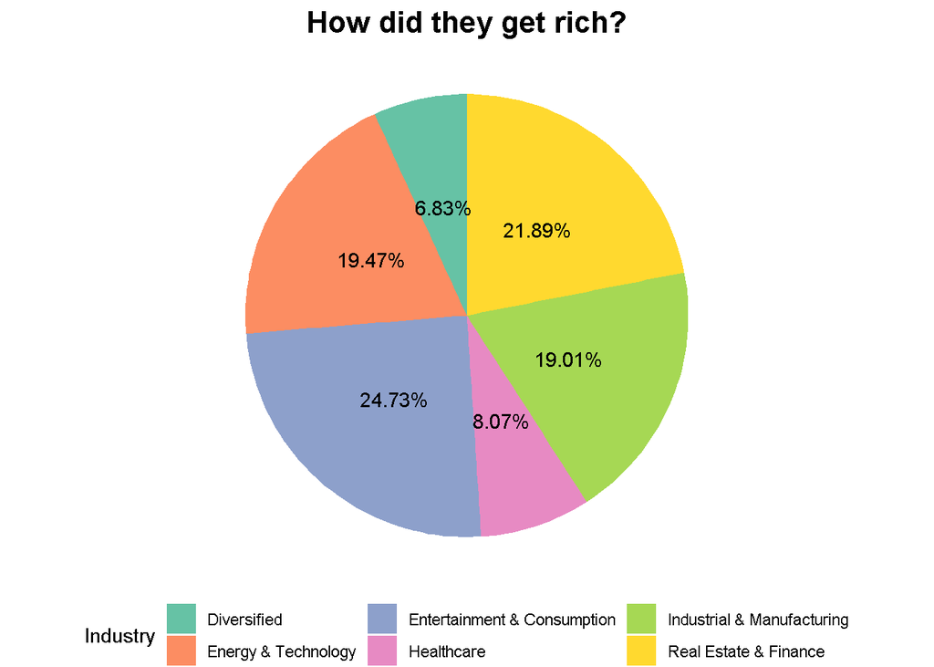

## Hypothesis 3 and Regression

### Test: Plot and Regression

The hypothesis to be tested is whether age is associated with net worth.

H0: Beta_age = 0

H1: Beta_age != 0

We plot the relationship between age and net worth and perform a regression analysis.

### Interpretation

One year increase in age is (potentially) associated with a 0.028 billion increase in net worth

The p-value is 0.09, which means we can reject the null hypothesis at the alpha = 0.1 significance level, but we fail to reject the null hypothesis at alpha = 0.05 significance level

### Conclusion

It appears to be that an increase in age is somewhat correlated to an increase in net worth, but the evidence is weak, and there are many potential hidden confounders which were not adressed.

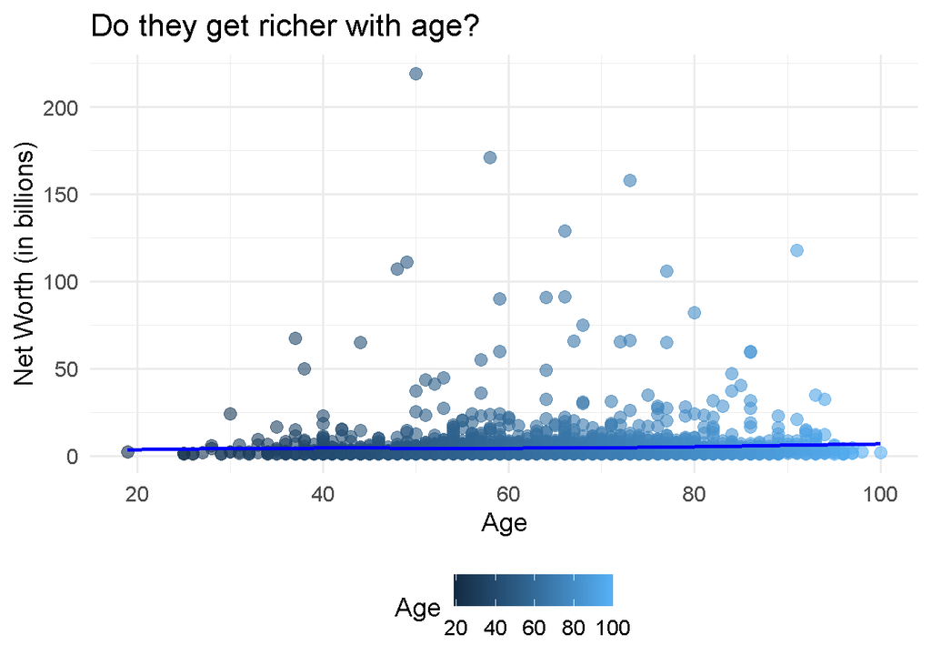

```
##
## t test of coefficients:
##
##             Estimate Std. Error t value Pr(>|t|)
## (Intercept) 2.985972   1.110129  2.6898 0.007199 **
## Age         0.028255   0.016681  1.6938 0.090425 .
## ---
## Signif. codes:  0 '***' 0.001 '**' 0.01 '*' 0.05 '.' 0.1 ' ' 1
```